# Some Exploratory Data Analysis of the Antiwork and TwoXChromosomes subreddits

```python
import pandas as pd
import numpy as np
import seaborn as sns
import matplotlib.pyplot as plt

import datetime as dt
```

```python
dfaw = pd.read_pickle('antiworkall.pkl')
dfxx = pd.read_pickle('xxall.pkl')
```

# Most popular posts

Antiwork post results in Subreddit going viral

```python
print(dfxx.loc[dfxx.score.idxmax()].created_time)
print('https://www.reddit.com/'+dfxx.loc[dfxx.score.idxmax()].permalink)
print(dfaw.loc[dfaw.score.idxmax()].created_time)
print('https://www.reddit.com/'+dfaw.loc[dfaw.score.idxmax()].permalink)
```

```
2021-02-21 15:44:40
https://www.reddit.com//r/TwoXChromosomes/comments/lozncd/in_2009_colorado_began_offering_teens_free_iuds/
2021-10-14 16:10:43
https://www.reddit.com//r/antiwork/comments/q82vqk/quit_my_job_last_night_it_was_nice_to_be_home_to/
```

## investigating difference between retrieving and creating time

```python
## todo
# dfxx.created_utc-dfxx.retrieved_utc
```

## Investigating the popularity of the subreddits

```
2021-10-14 00:00:00
```

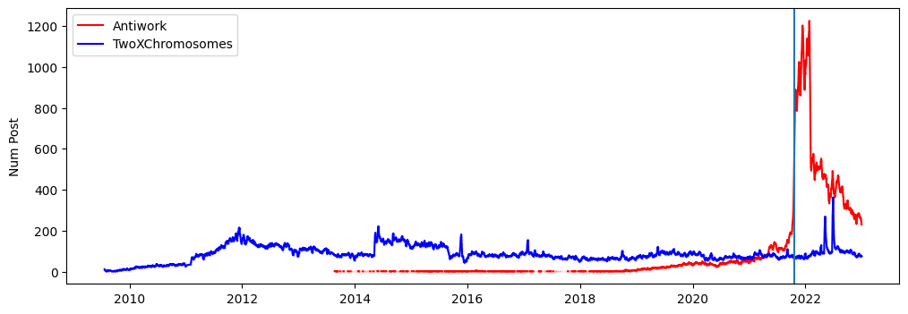

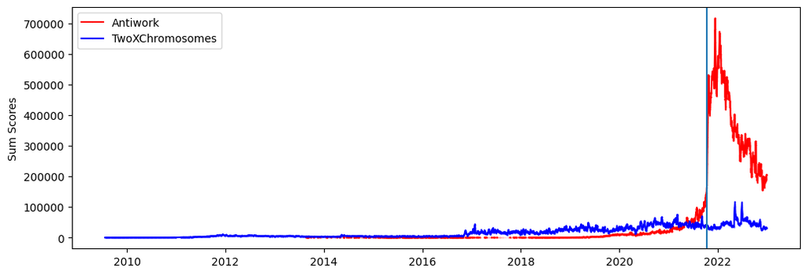

```python
#dfxx.groupby(dfxx.created_time.dt.date).size().\
#    to_frame().rolling(7).mean().merge(dfaw.groupby(dfaw.created_time.dt.date).size().to_frame().rolling(7).mean(),left_index=True, right_index=True).\
#    rename(columns={'0_x':'XX','0_y':'Antiwork'}).plot()
#
x = dfxx.groupby(dfxx.created_time.dt.date).size().\
    to_frame().rolling(7).mean().rename(columns={0:'XX'}).\
        join(dfaw.groupby(dfaw.created_time.dt.date).size().to_frame().rolling(7).mean().rename(columns={0:'Antiwork'}))
x.index = pd.to_datetime(x.index)

#plt.figure()
##plt.plot_date(x.dropna(subset='Antiwork').index,x.dropna(subset='Antiwork').Antiwork.values,linestyle='-', marker='',color='r',)
#plt.plot_date(x.index,np.log(x.Antiwork.values),linestyle='-', marker='',color='r',label='Antiwork')
#plt.plot_date(x.index,np.log(x.XX.values),linestyle='-', marker='',color='b',label='TwoXChromosomes')
#plt.legend()
plt.figure(figsize=(12,4))
plt.plot_date(x.index,x.Antiwork.values,linestyle='-',markersize=0.1, color='r',label='Antiwork')
plt.plot_date(x.index,x.XX.values,linestyle='-',markersize=0.1,color='b',label='TwoXChromosomes')
plt.legend()
plt.ylabel('Num Post')
plt.axvline(x.resample('3D').last().diff().idxmax().iloc[1])
#
x = dfxx.groupby(dfxx.created_time.dt.date).score.sum().\
    to_frame().rolling(7).mean().rename(columns={'score':'XX'}).\
        join(dfaw.groupby(dfaw.created_time.dt.date).score.sum().to_frame().rolling(7).mean().rename(columns={'score':'Antiwork'}))
x.index = pd.to_datetime(x.index)
plt.figure(figsize=(12,4))
plt.plot_date(x.index,x.Antiwork.values,linestyle='-',markersize=0.1,color='r',label='Antiwork')
plt.plot_date(x.index,x.XX.values,linestyle='-',markersize=0.1,color='b',label='TwoXChromosomes')
#plt.axvline(dt.datetime(2021 ,11, 23))
print(x.resample('3D').last().diff().idxmax().iloc[1])
plt.axvline(x.resample('3D').last().diff().idxmax().iloc[1])

plt.legend()
plt.ylabel('Sum Scores')
```

The plots show a rolling mean of 7 days.

Vertical line shows the date of the (most) viral post for the antiwork subreddit on the 2021-10-14. Antiwork got featured in many news outlets around the US during that time

## Title length

```python
dfaw['textlen'] = dfaw.selftext.apply(lambda x: len(x))
dfxx['textlen'] = dfxx.selftext.apply(lambda x: len(x))
dfaw['titlelen'] = dfaw.title.apply(lambda x: len(x))
dfxx['titlelen'] = dfxx.title.apply(lambda x: len(x))

dfaw['textwordcount'] = dfaw.selftext.apply(lambda x: len(x.split()))
dfxx['textwordcount'] = dfxx.selftext.apply(lambda x: len(x.split()))
dfaw['titlewordcount'] = dfaw.title.apply(lambda x: len(x.split()))
dfxx['titlewordcount'] = dfxx.title.apply(lambda x: len(x.split()))
```

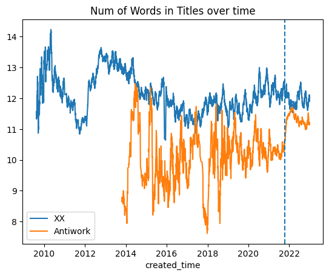

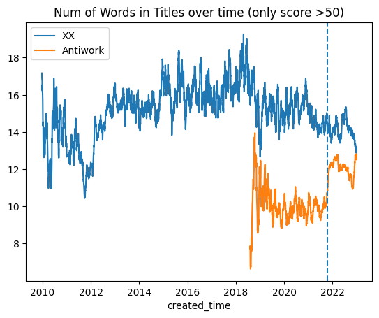

```python
#fig,ax= plt.subplots()
#dfxx.loc[dfxx.score>50].groupby(dfxx.created_time.dt.date).titlelen.mean().\
#    to_frame().rolling(30).mean().rename(columns={'titlelen':'XX'}).plot(ax=ax)
#
#dfaw.loc[dfaw.score>50].groupby(dfaw.created_time.dt.date).titlelen.mean().\
#    to_frame().rolling(30).mean().rename(columns={'titlelen':'Antiwork'}).plot(ax=ax)
#
#ax.axvline(x.resample('3D').last().diff().idxmax().iloc[1], linestyle = 'dashed')
#ax.set_title('Num of Letters in Titles over time')
fig,ax= plt.subplots()
dfxx.groupby(dfxx.created_time.dt.date).titlewordcount.mean().\
    to_frame().rolling(30).mean().rename(columns={'titlewordcount':'XX'}).plot(ax=ax)

dfaw.groupby(dfaw.created_time.dt.date).titlewordcount.mean().\
    to_frame().rolling(30).mean().rename(columns={'titlewordcount':'Antiwork'}).plot(ax=ax)

ax.axvline(x.resample('3D').last().diff().idxmax().iloc[1], linestyle = 'dashed')
ax.set_title('Num of Words in Titles over time')
fig,ax= plt.subplots()
dfxx.loc[dfxx.score>50].groupby(dfxx.created_time.dt.date).titlewordcount.mean().\
    to_frame().rolling(30).mean().rename(columns={'titlewordcount':'XX'}).plot(ax=ax)

dfaw.loc[dfaw.score>50].groupby(dfaw.created_time.dt.date).titlewordcount.mean().\
    to_frame().rolling(30).mean().rename(columns={'titlewordcount':'Antiwork'}).plot(ax=ax)

ax.axvline(x.resample('3D').last().diff().idxmax().iloc[1], linestyle = 'dashed')
ax.set_title('Num of Words in Titles over time (only score >50)')
```

## Word Count in title and text

text seems unimportant in viral posts. Mostly pictures/ screenshots

### TwoXXChromosomes

```python
dfxx.loc[dfxx.score>1000].textwordcount.value_counts(ascending=False,normalize=True).head()
```

```
0      0.339876
135    0.003304
1      0.002526
136    0.002429
150    0.002429
Name: textwordcount, dtype: float64
```

33 % of the viral plots (score > 1000) have no text

```python
#dfxx.loc[dfxx.score>1000].textwordcount.hist(bins=np.arange(1,1000,40))
```

```python
Explore = pd.DataFrame(columns=[10,100,200,500,1000,10000], index=[50,100,200,500,1000])
for sc in Explore.columns:
    for wc in Explore.index:
        Explore.loc[wc,sc] = len(dfxx.loc[(dfxx.score>sc) & (dfxx.textwordcount>wc)])
Explore.index.name = '> Words'
Explore.columns.name = '> Score'
Explore
```

| > Score > Words | 10 | 100 | 200 | 500 | 1000 | 10000 |
| --- | --- | --- | --- | --- | --- | --- |
| 50 | 71939 | 20273 | 14299 | 9257 | 6390 | 1388 |
| 100 | 61358 | 17742 | 12560 | 8195 | 5695 | 1247 |
| 200 | 41463 | 12450 | 8853 | 5874 | 4138 | 933 |
| 500 | 11818 | 3655 | 2630 | 1783 | 1253 | 290 |
| 1000 | 2180 | 642 | 443 | 309 | 216 | 53 |

Number of posts with a score above 1000 and more than 100 words as text.

### Antiwork

```python
dfaw.loc[dfaw.score>1000].textwordcount.value_counts(ascending=False,normalize=True).head()
```

```
0      0.820680
121    0.001206
116    0.001154
105    0.001101
46     0.000996
Name: textwordcount, dtype: float64
```

82 % of the viral posts have no text

```python
#dfaw.loc[dfaw.score>1000].textwordcount.hist(bins=np.arange(1,1000,40))
```

```python
Explore = pd.DataFrame(columns=[10,100,200,500,1000,10000], index=[50,100,200,500,1000])
for sc in Explore.columns:
    for wc in Explore.index:
        Explore.loc[wc,sc] = len(dfaw.loc[(dfaw.score>sc) & (dfaw.textwordcount>wc)])
Explore.index.name = '> Words'
Explore.columns.name = '> Score'
Explore
```

| > Score > Words | 10 | 100 | 200 | 500 | 1000 | 10000 |
| --- | --- | --- | --- | --- | --- | --- |
| 50 | 56104 | 9784 | 6322 | 4011 | 3006 | 794 |
| 100 | 43441 | 7784 | 5106 | 3297 | 2496 | 674 |
| 200 | 24291 | 4446 | 3000 | 1978 | 1511 | 434 |
| 500 | 5362 | 1001 | 692 | 470 | 365 | 113 |
| 1000 | 968 | 174 | 116 | 76 | 58 | 12 |

### Title word count

Showing that XX has segnificantly longer titles than Antiwork

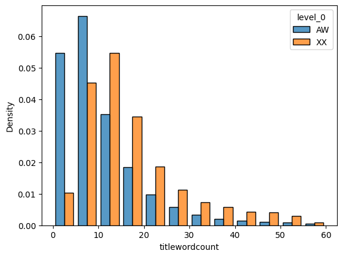

```python
fig,ax= plt.subplots()

sns.histplot(data =pd.concat([dfaw.loc[dfaw.score>1000].titlewordcount, dfxx.loc[dfxx.score>1000].titlewordcount], keys=['AW', 'XX']).reset_index(level=[0,1]),
    x = 'titlewordcount',
    hue = 'level_0',
    bins=np.arange(-0.01,60,5),
    stat="density",
    ax= ax,
    legend=True,
    common_norm=False,
    multiple="dodge",
    shrink=.8
    )
```

```python
#dfaw.loc[dfaw.score>15000].titlewordcount.hist(bins=np.linspace(0,60,20),alpha=0.5,density=True)
#dfxx.loc[dfxx.score>15000].titlewordcount.hist(bins=np.linspace(0,60,20),alpha=0.5,density=True)
```

# Word count of posts

Also on average the number of words in posts are segnificantly higher in XX.

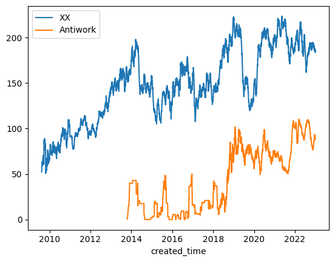

```python
fig,ax= plt.subplots()
dfxx.groupby(dfxx.created_time.dt.date).textwordcount.mean().\
    to_frame().rolling(30).mean().rename(columns={'textwordcount':'XX'}).plot(ax=ax)

dfaw.groupby(dfaw.created_time.dt.date).textwordcount.mean().\
    to_frame().rolling(30).mean().rename(columns={'textwordcount':'Antiwork'}).plot(ax=ax)
```

# Score Distributions

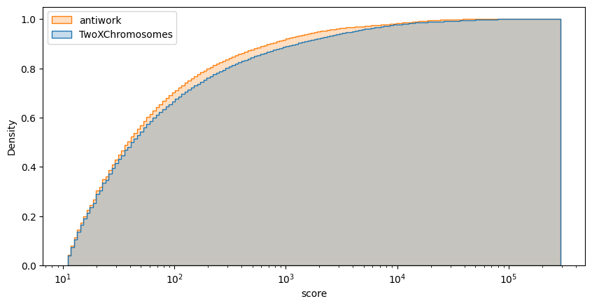

```python
fig,ax = plt.subplots()
fig.set_figwidth(10)
g = sns.histplot(data=pd.concat([dfaw.loc[dfaw.score>10][['score','subreddit']],dfxx.loc[dfxx.score>10][['score','subreddit']]]),
    x='score',
    log_scale=True,
    hue= 'subreddit',
    #multiple="dodge",
    stat = 'density',
    common_norm=False,
    cumulative=True,
    element="step",
    ax=ax,
    )

g.legend(loc = 2,labels=['antiwork','TwoXChromosomes'])
```

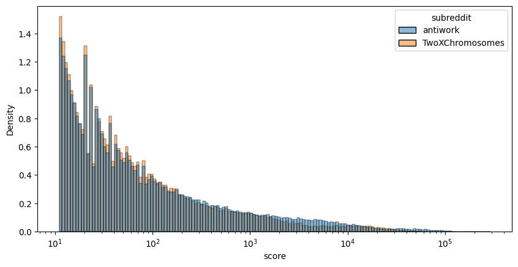

```python
fig,ax = plt.subplots()
fig.set_figwidth(10)
g = sns.histplot(data=pd.concat([dfaw.loc[dfaw.score>10][['score','subreddit']],dfxx.loc[dfxx.score>10][['score','subreddit']]]),
    x='score',
    log_scale=True,
    hue= 'subreddit',
    #multiple="dodge",
    stat = 'density',
    common_norm=False,
    cumulative=False,
    #element="step",
    ax=ax,
    )
```

# Time dependency of plots

## Time of week

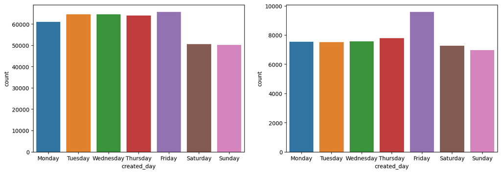

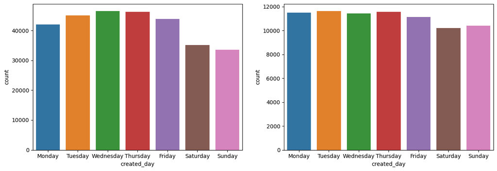

```python
fig,ax =plt.subplots(ncols=2)
fig.set_figwidth(15)
sns.countplot(data=dfxx, x='created_day',order=['Monday', 'Tuesday', 'Wednesday', 'Thursday',
       'Friday','Saturday', 'Sunday', ], ax = ax[0])
sns.countplot(data=dfxx.loc[dfxx.score>50], x='created_day',order=['Monday', 'Tuesday', 'Wednesday', 'Thursday',
       'Friday','Saturday', 'Sunday', ], ax = ax[1])

plt.figure()
fig, ax = plt.subplots(ncols=2)
fig.set_figwidth(15)
sns.countplot(data=dfaw, x='created_day',order=['Monday', 'Tuesday', 'Wednesday', 'Thursday',
       'Friday','Saturday', 'Sunday', ], ax = ax[0])
sns.countplot(data=dfaw.loc[dfaw.score>50], x='created_day',order=['Monday', 'Tuesday', 'Wednesday', 'Thursday',
       'Friday','Saturday', 'Sunday', ], ax = ax[1])
```

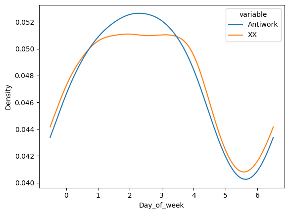

```python
dataaw = pd.concat([dfaw.created_time.dt.day_of_week+7, dfaw.created_time.dt.day_of_week-7 ,dfaw.created_time.dt.day_of_week], ignore_index=True).to_frame().rename(columns={'created_time': 'Antiwork'})
#a = sns.kdeplot(data = data, x='created_time',clip=(-0.5, 23.5),legend=True)

dataxx = pd.concat([dfxx.created_time.dt.day_of_week+7, dfxx.created_time.dt.day_of_week-7 ,dfxx.created_time.dt.day_of_week], ignore_index=True).to_frame().rename(columns={'created_time': 'XX'})
data= pd.concat([dataaw,dataxx]).melt(value_name='Day_of_week')
sns.kdeplot(data = data, x='Day_of_week',hue='variable',bw_adjust=1.8,clip=(-0.5, 6.5),common_norm=False,legend=True)
#plt.legend(handles=['Antiwork','XX'])
```

## Time of day

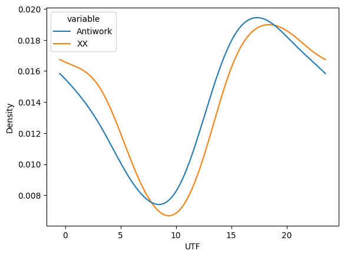

```python
dataaw = pd.concat([dfaw.created_time.dt.hour+24, dfaw.created_time.dt.hour-24 ,dfaw.created_time.dt.hour], ignore_index=True).to_frame().rename(columns={'created_time': 'Antiwork'})
#a = sns.kdeplot(data = data, x='created_time',clip=(-0.5, 23.5),legend=True)

dataxx = pd.concat([dfxx.created_time.dt.hour+24, dfxx.created_time.dt.hour-24 ,dfxx.created_time.dt.hour], ignore_index=True).to_frame().rename(columns={'created_time': 'XX'})
data= pd.concat([dataaw,dataxx]).melt(value_name='UTF')
sns.kdeplot(data = data, x='UTF',hue='variable',clip=(-0.5, 23.5),common_norm=False,legend=True)
#plt.legend(handles=['Antiwork','XX'])
```

# Wordclouds

A step to show the words used in the most viral posts on both subreddits. Using the titles only

```python
from wordcloud import WordCloud, STOPWORDS
import re
import string
stopwords = set(STOPWORDS)
stopwords.update(['amp'])
def tokenize(text):
    """
    Parses a string into a list of semantic units (words)
    Args:
        text (str): The string that the function will tokenize.
    Returns:
        list: tokens parsed out
    """
    # Removing url's
    pattern = r"http\S+"

    text = re.sub(pattern, "", text) # https://www.youtube.com/watch?v=O2onA4r5UaY

    text = re.sub('[^a-zA-Z 0-9]', '', text)
    text = re.sub('[%s]' % re.escape(string.punctuation), '', text) # Remove punctuation
    text = re.sub('\w*\d\w*', '', text) # Remove words containing numbers
    tokens = re.sub('(\\b[A-Za-z] \\b|\\b [A-Za-z]\\b)', '', text)
    #print(tokens)
    #tokens = re.sub('@*!*$*', '', text) # Remove @ ! $
    tokens = tokens.strip(',') # TESTING THIS LINE
    tokens = tokens.strip('?') # TESTING THIS LINE
    tokens = tokens.strip('!') # TESTING THIS LINE
    #tokens = tokens.strip("'") # TESTING THIS LINE
    tokens = tokens.strip(".") # TESTING THIS LINE

    tokens = tokens.lower().split() # Make text lowercase and split it


    return tokens
```

Using only 500 highest rated posts in XX:

[figure not shown]

```python
flatl = [item for sublist in list(dfxx.sort_values(by='score',ascending=False).head(500).title.apply(tokenize)) for item in sublist]
long_string = ','.join(list(flatl))
#long_string = long_string+ ','.join(list(df['title_processed'].values))
wordcloud = WordCloud(background_color="white", max_words=100, contour_width=3, stopwords=stopwords,contour_color='steelblue',width=1600, height=800)# Generate a word cloud
wordcloud.generate(long_string)# Visualize the word cloud
wordcloud.to_image()
```

```python
#print(len(dfxx.loc[dfxx.score>15000]))
#flatl = [item for sublist in list(dfxx.loc[dfxx.score>15000].title.apply(tokenize)) for item in sublist]
#long_string = ','.join(list(flatl))
#wordcloud = WordCloud(background_color="white", max_words=100, contour_width=3, stopwords=stopwords,contour_color='steelblue',width=1600, height=800)# Generate a word cloud
#wordcloud.generate(long_string)# Visualize the word cloud
#wordcloud.to_image()
```

Using only 500 highest rated posts in Antiwork:

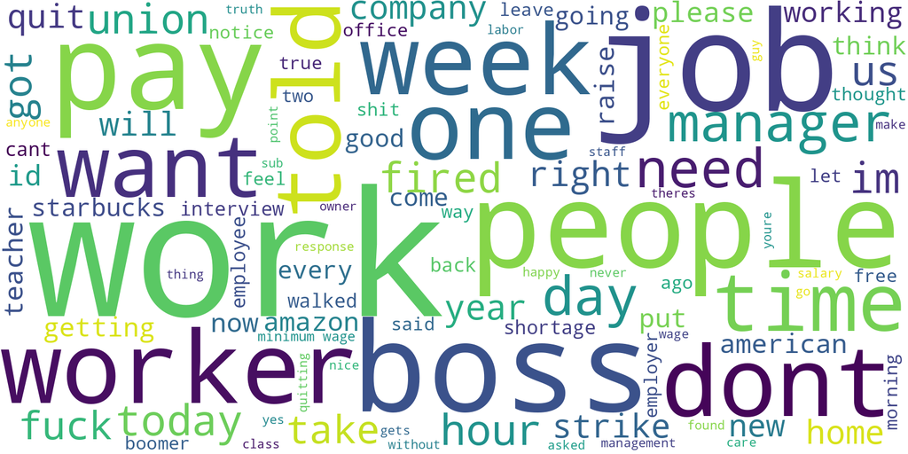

```python
#flatl = [item for sublist in list(dfaw.loc[dfaw.score>15000].title.apply(tokenize)) for item in sublist]
flatl = [item for sublist in list(dfaw.sort_values(by='score',ascending=False).head(500).title.apply(tokenize)) for item in sublist]
long_string = ','.join(list(flatl))
#long_string = long_string+ ','.join(list(df['title_processed'].values))

wordcloud = WordCloud(background_color="white", max_words=100, contour_width=3, stopwords=stopwords, contour_color='back',width=1600, height=800)# Generate a word cloud
wordcloud.generate(long_string)# Visualize the word cloud
wordcloud.to_image()
```